# DATA 608 HW 1

Albert Gilharry

September 6, 2018

```r
library("dplyr")
library("ggplot2")
library("scales")
```

**Principles of Data Visualization and Introduction to ggplot2**

I have provided you with data about the 5,000 fastest growing companies in the US, as compiled by Inc. magazine. lets read this in:

```r
inc <- read.csv("https://raw.githubusercontent.com/charleyferrari/CUNY_DATA_608/master/module1/Data/inc5000_data.csv", header= TRUE)
```

And lets preview this data:

```r
head(inc)
```

|  | Rank | Name | Growth_Rate | Revenue | Industry | Employees | City | State |
| --- | --- | --- | --- | --- | --- | --- | --- | --- |
| 1 | 1 | Fuhu | 421.48 | 1.179e+08 | Consumer Products & Services | 104 | El Segundo | CA |
| 2 | 2 | FederalConference.com | 248.31 | 4.960e+07 | Government Services | 51 | Dumfries | VA |
| 3 | 3 | The HCI Group | 245.45 | 2.550e+07 | Health | 132 | Jacksonville | FL |
| 4 | 4 | Bridger | 233.08 | 1.900e+09 | Energy | 50 | Addison | TX |
| 5 | 5 | DataXu | 213.37 | 8.700e+07 | Advertising & Marketing | 220 | Boston | MA |
| 6 | 6 | MileStone Community Builders | 179.38 | 4.570e+07 | Real Estate | 63 | Austin | TX |

```r
summary(inc)
```

```
      Rank                          Name       Growth_Rate         Revenue                                  Industry      Employees                  City
 Min.   :   1   (Add)ventures         :   1   Min.   :  0.340   Min.   :2.000e+06   IT Services                 : 733   Min.   :    1.0   New York     : 160
 1st Qu.:1252   @Properties           :   1   1st Qu.:  0.770   1st Qu.:5.100e+06   Business Products & Services: 482   1st Qu.:   25.0   Chicago      :  90
 Median :2502   1-Stop Translation USA:   1   Median :  1.420   Median :1.090e+07   Advertising & Marketing     : 471   Median :   53.0   Austin       :  88
 Mean   :2502   110 Consulting        :   1   Mean   :  4.612   Mean   :4.822e+07   Health                      : 355   Mean   :  232.7   Houston      :  76
 3rd Qu.:3751   11thStreetCoffee.com  :   1   3rd Qu.:  3.290   3rd Qu.:2.860e+07   Software                    : 342   3rd Qu.:  132.0   San Francisco:  75
 Max.   :5000   123 Exteriors         :   1   Max.   :421.480   Max.   :1.010e+10   Financial Services          : 260   Max.   :66803.0   Atlanta      :  74
                (Other)               :4995                                         (Other)                     :2358   NA's   :12        (Other)      :4438
     State
 CA     : 701
 TX     : 387
 NY     : 311
 VA     : 283
 FL     : 282
 IL     : 273
 (Other):2764
```

Think a bit on what these summaries mean. Use the space below to add some more relevant non-visual exploratory information you think helps you understand this data:

```r
# Insert your code here, create more chunks as necessary
print(paste0("There are ", nrow(inc[!complete.cases(inc),]), " incomplete cases in this data set."))
```

```
[1] "There are 12 incomplete cases in this data set."
```

```r
print(paste0("There are ", length(unique(inc$City)), " cities represented in this data set."))
```

[output not shown]

```r
print(paste0("There standard deviation of Growth_Rate is ", round(sd((inc$Growth_Rate)),2), "."))
```

```
[1] "There standard deviation of Growth_Rate is 14.12."
```

```r
print(paste0("There standard deviation of Revenue is ", round(sd((inc$Revenue)),4), "."))
```

```
[1] "There standard deviation of Revenue is 240542281.1359."
```

```r
print(paste0("There standard deviation of Employees is ", round(sd((na.omit(inc$Employees))),4), "."))
```

```
[1] "There standard deviation of Employees is 1353.1279."
```

## Question 1

Create a graph that shows the distribution of companies in the dataset by State (ie how many are in each state). There are a lot of States, so consider which axis you should use. This visualization is ultimately going to be consumed on a ‘portrait’ oriented screen (ie taller than wide), which should further guide your layout choices.

- I will create a histogram sorted by frequencies of companies in each state. My assumption is that this graphic is primarily intended for business purposes and having it sorted this way will better inform investment and other business decisions, by highlighting possible saturated markets and identifying possible areas for opportunities.

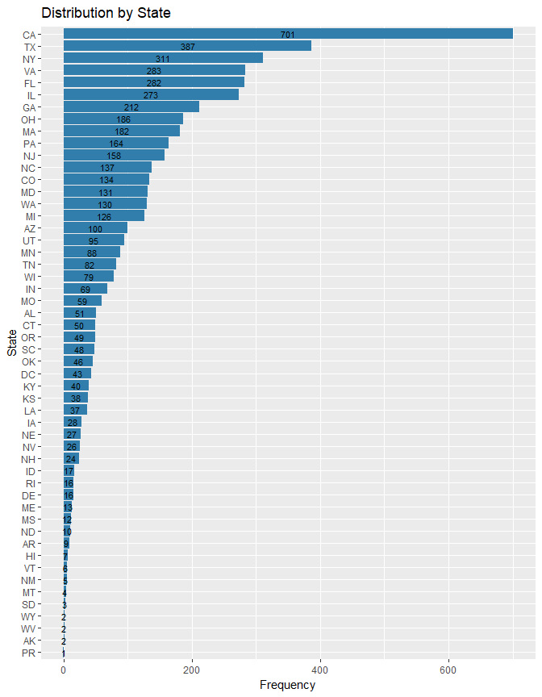

```r
# Answer Question 1 here
group_by(inc, State) %>%
  summarize( count = n() ) %>%
  arrange(desc(State)) %>%
  ggplot(aes( x = reorder(State,count), y = count, label = count, fill= State )) +
  geom_bar( stat='identity', show.legend = F, fill="#317EAC" ) +
  geom_text(size = 3, position = position_stack(vjust = 0.5)) +
  labs(title = "Distribution by State", x = "State", y = "Frequency" ) +
  coord_flip()
```

## Quesiton 2

Lets dig in on the state with the 3rd most companies in the data set. Imagine you work for the state and are interested in how many people are employed by companies in different industries. Create a plot that shows the average and/or median employment by industry for companies in this state (only use cases with full data, use R’s `complete.cases()` function.) In addition to this, your graph should show how variable the ranges are, and you should deal with outliers.

- The results from the previous question showed that the state with the third most companies is NY. I will plot the median because the variable `Employees` has some very large outliers, but is this also the case for NY?

```r
complete_cases_ny <- inc[complete.cases(inc),] %>%
  filter(State == 'NY')  %>%
  arrange(desc(Employees))
  head(complete_cases_ny)
```

|  | Rank | Name | Growth_Rate | Revenue | Industry | Employees | City | State |
| --- | --- | --- | --- | --- | --- | --- | --- | --- |
| 1 | 4577 | Sutherland Global Services | 0.48 | 5.976e+08 | Business Products & Services | 32000 | Pittsford | NY |
| 2 | 4936 | Coty | 0.36 | 4.600e+09 | Consumer Products & Services | 10000 | New York | NY |
| 3 | 4716 | Westcon Group | 0.44 | 3.800e+09 | IT Services | 3000 | Tarrytown | NY |
| 4 | 3899 | Denihan Hospitality Group | 0.71 | 2.808e+08 | Travel & Hospitality | 2280 | New York | NY |
| 5 | 4363 | TransPerfect | 0.55 | 3.413e+08 | Business Products & Services | 2218 | New York | NY |
| 6 | 1499 | Sterling Infosystems | 2.66 | 2.149e+08 | Human Resources | 2081 | New York | NY |

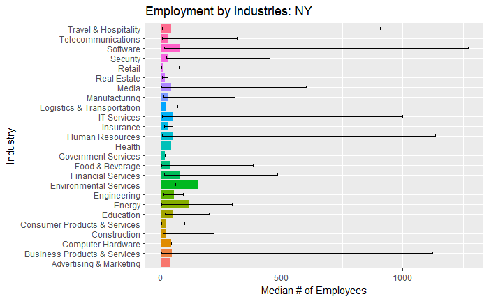

```r
  # Answer Question 2 here
  complete_cases_ny$Employees[complete_cases_ny$Employees > 1*sd(complete_cases_ny$Employees)] <- median(complete_cases_ny$Employees)
  complete_cases_ny %>%
  group_by(Industry) %>%
  summarize(med = median(Employees), mx = max(Employees), mn = min(Employees), avg = mean(Employees)) %>%
  ggplot(aes(x = Industry, y = med,  fill=Industry, label = med)) +
  geom_bar( stat='identity', show.legend = F ) +
  geom_errorbar(aes(ymin = mn, ymax = mx), position = "dodge", width = 0.25) +
  labs(title = "Employment by Industries: NY", x = "Industry", y = "Median # of Employees" ) +
  coord_flip()
```

## Question 3

Now imagine you work for an investor and want to see which industries generate the most revenue per employee. Create a chart that makes this information clear. Once again, the distribution per industry should be shown.

- I will use only complete cases. I wil also use the entire data set, assuming this question is independent of Question 2.

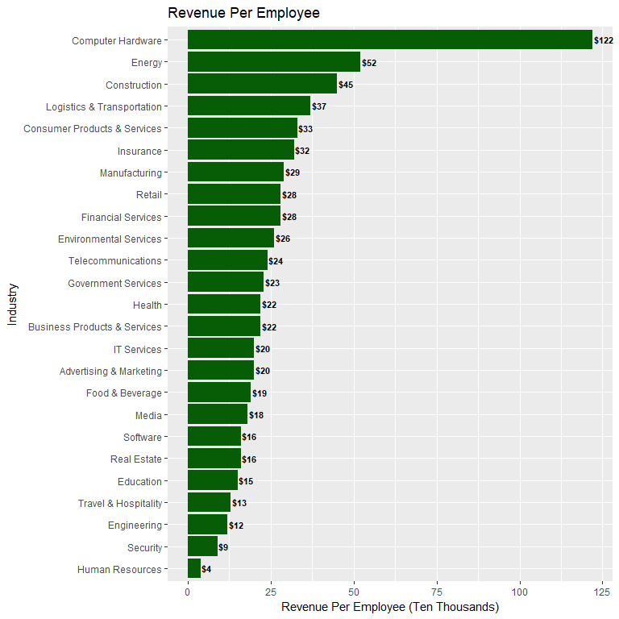

```r
# Answer Question 3 here
revenues <- inc[complete.cases(inc),] %>%
  group_by(Industry) %>%
  summarize(RPE = round((sum(Revenue)/sum(Employees))/10000))

  ggplot(revenues, aes(x = reorder(Industry,RPE), y = RPE,  fill=Industry, label = RPE)) +
  geom_bar( stat='identity', show.legend = F, fill="#065d06" ) +
  #scale_y_continuous(labels=dollar_format(suffix="0K")) +
  labs(title = "Revenue Per Employee", x = "Industry", y = "Revenue Per Employee (Ten Thousands)" ) +
  geom_text(data = revenues, size = 3, vjust = 0.5, color = "#000000", hjust=-0.1, label = dollar(revenues$RPE), fontface = 2 ) +
  coord_flip()
```